# CA5

**AI Fall 98 Project 5**

## Introduction

The intent of the classification process is to categorize all pixels in a digital image into one of several classes, or "themes". Normally, multispectral data are used to perform the classification and the spectral pattern present within the data for each pixel is used as the numerical basis for categorization. The objective of image classification is to identify and portray, as a unique gray level (or color), the features occurring in an image.

## Definition of Question

The goal of this project is to classify images and predict their classes. The dataset used in this project consists of 52 classes, and each class has up to 4 thousand images. Each image is a colored image with the size of 60*80 pixels. To do such goal, a neural network model is built and its hyper parameters are tuned in each part to reach the best accuracy.

## Part 1

```python
from google.colab import drive
drive.mount('/content/drive')
!unzip -n "drive/My Drive/Colab Notebooks/categorized_products.zip"
```

```python
import torchvision
import torch
import matplotlib.pyplot as plt
import tensorflow as tf
from torch.utils.data import Dataset, DataLoader, random_split
from torchvision.datasets import ImageFolder
from torch.utils.data.sampler import SubsetRandomSampler
import torchvision.transforms as transforms
import numpy as np
from random import randrange
from sklearn.model_selection import train_test_split
from random import shuffle
import torch.nn as nn
import torch.nn.functional as F
import time
from datetime import timedelta
from datetime import datetime
```

```python
class CustomToTensor(object):
  def __call__(self, image):
    image = np.array(image, dtype=np.float32)
    # numpy image: H x W
    return torch.from_numpy(image)
```

```python
def imshow(img_array, labels, classes):
  _, axs = plt.subplots(3, 4)
  for i in range(3):
    for j in range(4):
      axs[i][j].imshow(img_array[i * 4 + j], cmap='gray')
      axs[i][j].set_title(classes[labels[i * 4 + j]])
      axs[i][j].axis('off')
  plt.tight_layout()
  plt.show()
```

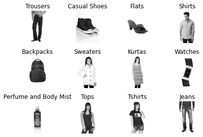

```python
transform = transforms.Compose([transforms.Grayscale(), CustomToTensor()])
dataset = ImageFolder('./categorized_products', transform=transform)
imageArray = list()
listArray = list()
while len(imageArray) < 12:
  randomNum = randrange(len(dataset))
  if dataset[randomNum][1] in listArray:
    continue
  imageArray.append(dataset[randomNum][0])
  listArray.append(dataset[randomNum][1])

imshow(imageArray, listArray, dataset.classes)
```

## Part 2

As seen in the following plot, image distribution between different classes are not equal and some classes have 100 images while other classes have up to 3500 images.

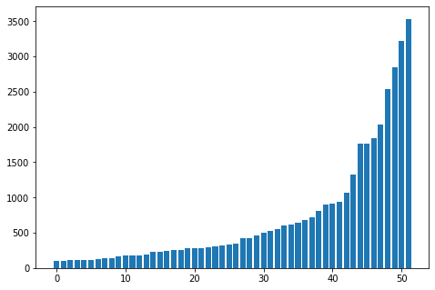

```python
from collections import Counter

class_counts = dict(Counter(sample_tup[1] for sample_tup in dataset))
sorted_class_counts = {k: v for k, v in sorted(class_counts.items(), key=lambda item: item[1])}

fig = plt.figure()
ax = fig.add_axes([0,0,1,1])
ax.bar(range(len(sorted_class_counts)), list(sorted_class_counts.values()))
plt.show()
```

```python
validation_split = 0.2

indices = list(range(len(dataset))) # indices of the dataset
train_indices = list()
test_indices = list()

last_index = 0
for key, value in class_counts.items():
  train, test = train_test_split(indices[last_index:last_index+value-1], test_size=validation_split)
  last_index += value
  train_indices.extend(train)
  test_indices.extend(test)

shuffle(train_indices)
```

```python
batch_size = 64

train_sampler = SubsetRandomSampler(train_indices)
test_sampler = SubsetRandomSampler(test_indices)

train_loader = torch.utils.data.DataLoader(dataset, batch_size=batch_size, sampler=train_sampler, num_workers=16)
test_loader = torch.utils.data.DataLoader(dataset, batch_size=batch_size, sampler=test_sampler, num_workers=16)
```

The model built in this project consists of 5 layers. An input layer, an output layer and three hidden layers. Each layer has different amount of neurons.  
Activation function takes in the output signal from the previous cell and converts it into some form that can be taken as input to the next cell.The activation function used in all layers is the same and the default activation function is `Relu` function. ReLU stands for rectified linear unit, and is a type of activation function. Mathematically, it is defined as y = max(0, x).

[figure not shown]

```python
class Model(nn.Module):
  def __init__(self, class_num, act=F.relu):
    super(Model, self).__init__()

    self.layer1 = nn.Linear(1 * 60 * 80, 16 * 30 * 40)
    self.act1 = act

    self.layer2 = nn.Linear(16 * 30 * 40, 48 * 10 * 15)
    self.act2 = act

    self.layer3 = nn.Linear(48 * 10 * 15, 96 * 2 * 3)
    self.act3 = act

    self.layer4 = nn.Linear(96 * 2 * 3, 82)
    self.act4 = act

    self.layer5 = nn.Linear(82, class_num)

  def forward(self, x):
    x = x.view(x.size(0), -1)

    x = self.layer1(x)
    x = self.act1(x)

    x = self.layer2(x)
    x = self.act2(x)

    x = self.layer3(x)
    x = self.act3(x)

    x = self.layer4(x)
    x = self.act4(x)

    x = self.layer5(x)

    return x
```

```python
device = torch.device("cuda:0" if torch.cuda.is_available() else "cpu")
print(device)
```

```
cuda:0
```

## Part 3

```python
model = Model(len(dataset.classes))
model = model.to(device)

learning_rate = 0.01
criterion = nn.CrossEntropyLoss()
optimizer = torch.optim.SGD(model.parameters(), lr=learning_rate)
```

```python
def count_parameters(model):
  total_param = 0
  for name, param in model.named_parameters():
    if param.requires_grad:
      num_param = np.prod(param.size())
      if param.dim() > 1:
        print(name, ':', 'x'.join(str(x) for x in list(param.size())), '=', num_param)
      else:
        print(name, ':', num_param)
      total_param += num_param
  return total_param
```

The first layer has 1*60*80 neurons and the second layer has 16*30*40 neurons. So, there are 1*60*80*16*30*40 = 92160000 total trainable weights between first and second layer because each neuron in the first layer is connected to all neurons in the second layer. Also, the second layer has 16*30*40 neurons so there are 19200 trainable biases in this layer. To calculate the number of all trainable parameters, trainable weights and biases are calclulated for each layer and summed.

```python
print('number of trainable parameters =', count_parameters(model))
```

```
layer1.weight : 19200x4800 = 92160000
layer1.bias : 19200
layer2.weight : 7200x19200 = 138240000
layer2.bias : 7200
layer3.weight : 576x7200 = 4147200
layer3.bias : 576
layer4.weight : 82x576 = 47232
layer4.bias : 82
layer5.weight : 52x82 = 4264
layer5.bias : 52
number of trainable parameters = 234625806
```

### Concepts:

1. **Criterion:** The Loss Function is one of the important components of Neural Networks. Loss is nothing but a prediction error of Neural Net. And the method to calculate the loss is called Loss Function. In simple words, the Loss is used to calculate the gradients. And gradients are used to update the weights of the Neural Net. Cross-entropy loss, or log loss, measures the performance of a classification model whose output is a probability value between 0 and 1. Cross-entropy loss increases as the predicted probability diverges from the actual label. So predicting a probability of .012 when the actual observation label is 1 would be bad and result in a high loss value.

[figure not shown]

2. **Optimizer:** Optimizers are algorithms or methods used to change the attributes of the neural network such as weights and learning rate to reduce the losses. Optimizers are used to solve optimization problems by minimizing the function. Gradient indicates the direction of increase. As we want to find the minimum point in the valley we need to go in the opposite direction of the gradient. We update parameters in the negative gradient direction to minimize the loss.

[figure not shown]

   θ is the weight parameter, η is the learning rate and ∇J(θ;x,y) is the gradient of weight parameter θ. Through backpropagation, the loss is transferred from one layer to another and the model’s parameters also known as weights are modified depending on the losses so that the loss can be minimized. In stochastic gradient descent we use a single datapoint or example to calculate the gradient and update the weights with every iteration. Learning is much faster and convergence is quick for a very large dataset.
3. **Epoch**: An epoch refers to one cycle through the full training dataset.

```python
def fit(model, train_loader, device, criterion, optimizer, num_epochs=10):

  total_time = 0.
  average_losses = list()

  for epoch in range(num_epochs):
    train_loss = 0.
    d1 = datetime.now()
    for images, labels in train_loader:

      images = images.to(device)
      labels = labels.to(device)

      # Clear gradients w.r.t. parameters
      optimizer.zero_grad()

      # Forward pass to get output/logits
      outputs = model(images)

      # Calculate Loss: softmax --> cross entropy loss
      loss = criterion(outputs, labels)

      # Getting gradients w.r.t. parameters
      loss.backward()

      # Updating parameters
      optimizer.step()
      train_loss += loss.item()

    average_loss = train_loss / len(train_loader)
    average_losses.append(average_loss)
    d2 = datetime.now()
    delta = d2 - d1
    seconds = float(delta.total_seconds())
    total_time += seconds
    print('epoch %d, train_loss: %.3f, time elapsed: %s seconds' % (epoch + 1, average_loss, seconds))

  print('total training time: %.3f minutes' % (total_time / 60))
  return average_losses
```

```python
def test_model_accuracy(model, test_loader):
  # Calculate Accuracy
  correct = 0.
  total = 0.
  # Iterate through test dataset
  with torch.no_grad():
    for images, labels in test_loader:
      outputs = model(images.to(device))
      _, predicted = torch.max(outputs.data, 1)
      total += labels.size(0)
      correct += (predicted.to('cpu') == labels).sum().item()

  accuracy = 100 * correct / total
  print('Accuracy: {}%'.format(accuracy))
```

```python
def test_model_accuracy_each_class(model, test_loader, train_loader):
  test_correct = np.zeros(len(dataset.classes), dtype=int)
  test_total = np.zeros(len(dataset.classes), dtype=int)
  with torch.no_grad():
    for images, labels in test_loader:
      outputs = model(images.to(device))
      _, predicted = torch.max(outputs.data, 1)
      predicted_array = predicted.to('cpu').tolist()
      labels_array = labels.tolist()
      for i in range(labels.size(0)):
        if labels_array[i] == predicted_array[i]:
          test_correct[labels_array[i]] += 1
        test_total[labels_array[i]] += 1

  train_correct = np.zeros(len(dataset.classes), dtype=int)
  train_total = np.zeros(len(dataset.classes), dtype=int)
  with torch.no_grad():
    for images, labels in train_loader:
      outputs = model(images.to(device))
      _, predicted = torch.max(outputs.data, 1)
      predicted_array = predicted.to('cpu').tolist()
      labels_array = labels.tolist()
      for i in range(labels.size(0)):
        if labels_array[i] == predicted_array[i]:
          train_correct[labels_array[i]] += 1
        train_total[labels_array[i]] += 1

  test_accuracy = list()
  train_accuracy = list()
  for i in range(len(dataset.classes)):
    if test_total[i] == 0:
      test_accuracy.append(0)
    else:
      test_accuracy.append(test_correct[i]/test_total[i]*100)

    if train_total[i] == 0:
      train_accuracy.append(0)
    else:
      train_accuracy.append(train_correct[i]/train_total[i]*100)

  # data to plot
  n_groups = len(dataset.classes)

  # create plot
  fig, ax = plt.subplots()
  index = np.arange(n_groups)
  bar_width = 0.4
  opacity = 0.8

  rects1 = plt.bar(index, test_accuracy, bar_width, alpha=opacity, color='b', label='Test Data')

  rects2 = plt.bar(index + bar_width, train_accuracy, bar_width, alpha=opacity, color='r', label='Train Data')

  plt.xlabel('Class')
  plt.ylabel('Accuracy')
  plt.title('Model Accuracy')
  plt.xticks(index + bar_width, range(len(dataset.classes)))
  plt.legend()

  plt.tight_layout()
  fig.set_size_inches(20, 10.5, forward=True)
  plt.show()
```

```python
def draw_average_loss_plot(average_losses):
  plt.plot(average_losses)
  plt.xticks(np.arange(10))
  plt.xlabel('Epoch')
  plt.ylabel('Loss')
  plt.title('Average Loss')
  plt.show()
```

In this part, dataset is not normalized so each pixel is between 0 and 255. This number is so big and causes the weights to have less effect on the output and the output ranges a lot. On the other hand, loss function output increases so much that becomes NAN. With these scenarios, our model's accuracy is less than 0.3% which is bad.

```python
average_losses = fit(model, train_loader, device, criterion, optimizer)
```

```
epoch 1, train_loss: nan, time elapsed: 24.488036 seconds
epoch 2, train_loss: nan, time elapsed: 24.41223 seconds
epoch 3, train_loss: nan, time elapsed: 24.42149 seconds
epoch 4, train_loss: nan, time elapsed: 24.688098 seconds
epoch 5, train_loss: nan, time elapsed: 24.672731 seconds
epoch 6, train_loss: nan, time elapsed: 24.56693 seconds
epoch 7, train_loss: nan, time elapsed: 24.657593 seconds
epoch 8, train_loss: nan, time elapsed: 25.049642 seconds
epoch 9, train_loss: nan, time elapsed: 24.606993 seconds
epoch 10, train_loss: nan, time elapsed: 24.67906 seconds
total training time: 4.104 minutes
```

```python
print('For Test: ')
test_model_accuracy(model, test_loader)
print('For Train: ')
test_model_accuracy(model, train_loader)
```

```
For Test:
Accuracy: 0.2948666398606085%
For Train:
Accuracy: 0.2959375840731773%
```

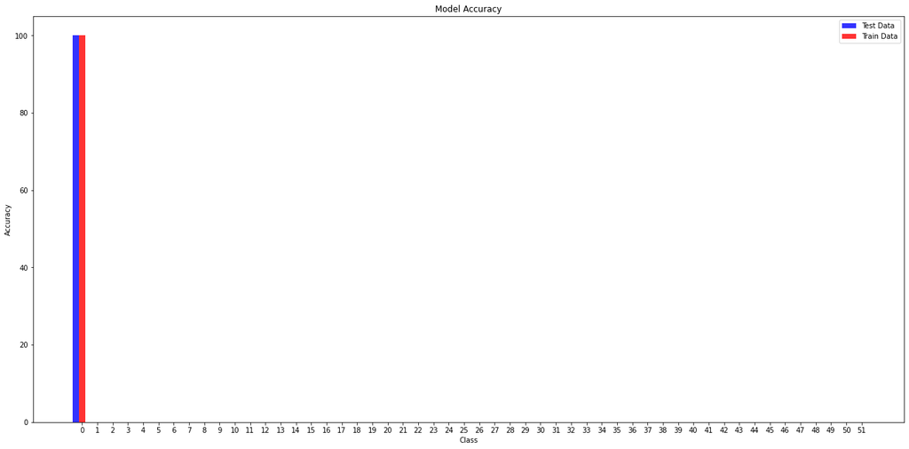

```python
test_model_accuracy_each_class(model, test_loader, train_loader)
```

[figure not shown]

```python
draw_average_loss_plot(average_losses)
```

## Part 4

In this part, each pixel is divided by 255 so the input range would be [0,1]. Normalization is useful when you want to make use of linear models and interpret their coefficients as variable importance. For instance, if one of the variables is in the range of 1000’s and another is in the range of 0.1’s then the coefficient found by Logistic Regression for the first variable would be (most likely) much larger than the coefficient for the second variable. This does not really show if the first variable is more important or not, but this coefficient needs to be large just to compensate for the scale of that variable. So, normalizing data would cause our model to work better than the last part and accuracy is much higher than the last part.

```python
class CustomToTensorNormalize(object):
  def __call__(self, image):
    image = np.array(image, dtype=np.float32) / 255
    # numpy image: H x W
    return torch.from_numpy(image)
```

```python
transform2 = transforms.Compose([transforms.Grayscale(), CustomToTensorNormalize()])
dataset2 = ImageFolder('./categorized_products', transform=transform2)

batch_size = 64

train_loader2 = torch.utils.data.DataLoader(dataset2, batch_size=batch_size, sampler=train_sampler, num_workers=16)
test_loader2 = torch.utils.data.DataLoader(dataset2, batch_size=batch_size, sampler=test_sampler, num_workers=16)

model2 = Model(len(dataset2.classes))
model2 = model2.to(device)

optimizer2 = torch.optim.SGD(model2.parameters(), lr=0.01)
```

```python
average_losses2 = fit(model2, train_loader2, device, criterion, optimizer2)
```

```
epoch 1, train_loss: 3.397, time elapsed: 24.992226 seconds
epoch 2, train_loss: 2.662, time elapsed: 25.151507 seconds
epoch 3, train_loss: 2.156, time elapsed: 25.391662 seconds
epoch 4, train_loss: 1.866, time elapsed: 25.263657 seconds
epoch 5, train_loss: 1.698, time elapsed: 25.318384 seconds
epoch 6, train_loss: 1.581, time elapsed: 25.269029 seconds
epoch 7, train_loss: 1.499, time elapsed: 25.390336 seconds
epoch 8, train_loss: 1.419, time elapsed: 25.29103 seconds
epoch 9, train_loss: 1.363, time elapsed: 25.39193 seconds
epoch 10, train_loss: 1.294, time elapsed: 25.284968 seconds
total training time: 4.212 minutes
```

```python
print('For Test: ')
test_model_accuracy(model2, test_loader2)
print('For Train: ')
test_model_accuracy(model2, train_loader2)
```

```
For Test:
Accuracy: 54.20184961801367%
For Train:
Accuracy: 54.78880817863869%
```

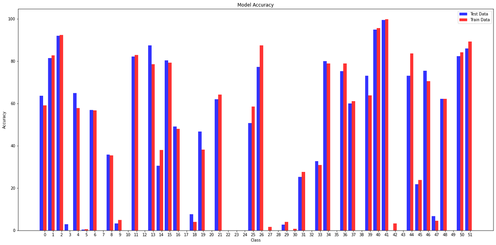

```python
test_model_accuracy_each_class(model2, test_loader2, train_loader2)
```

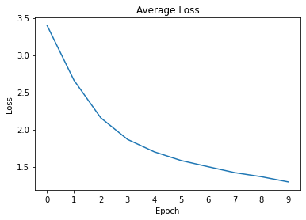

```python
draw_average_loss_plot(average_losses2)
```

## Part 5

As seen in the results, the accuracy of this model is much smaller than the last part and it is obvious that all of the predictions were wrong except for one class that has 100% accuracy. This phemomenon is illustrated in the following paragraph.  
Initializing all the weights with zeros leads the neurons to learn the same features during training. In fact, any constant initialization scheme will perform very poorly. Consider a neural network with two hidden units, and assume we initialize all the biases to 0 and the weights with some constant α. If we forward propagate an input (x1, x2) in this network, the output of both hidden units will be relu(α x1 + α x2). Thus, both hidden units will have identical influence on the cost, which will lead to identical gradients. Thus, both neurons will evolve symmetrically throughout training, effectively preventing different neurons from learning different things. So, the neurons can predict one class perefectly, however, the predictions for other classes are wrong.  
So, it is better to initialize weights and biases randomly than zero initialization. In this case, weights are usually different and the movement to optimum minimum takes place from different places and the chases of getting stuck in a local minima decreases. However, if weights are initialized with very high values the term W.X + b becomes significantly higher and and the activation function output increases and learning takes a lot of time. This is also possible when weights are initialized to small numbers. To prevent this, some initialization methods such as Xavier initialization are invented. Xavier initialization sets a layer’s weights to values chosen from a random uniform distribution that’s bounded between:

[figure not shown]

```python
def init_weights(m):
    if type(m) == nn.Linear:
        nn.init.zeros_(m.weight)
        m.bias.data.fill_(0)
```

```python
transform3 = transforms.Compose([transforms.Grayscale(), CustomToTensorNormalize()])
dataset3 = ImageFolder('./categorized_products', transform=transform3)

train_loader3 = torch.utils.data.DataLoader(dataset3, batch_size=batch_size, sampler=train_sampler, num_workers=16)
test_loader3 = torch.utils.data.DataLoader(dataset3, batch_size=batch_size, sampler=test_sampler, num_workers=16)

model3 = Model(len(dataset3.classes))
model3.apply(init_weights)
model3 = model3.to(device)

criterion3 = nn.CrossEntropyLoss()
optimizer3 = torch.optim.SGD(model3.parameters(), lr=0.01)
```

```python
average_losses3 = fit(model3, train_loader3, device, criterion3, optimizer3)
```

```
epoch 1, train_loss: 3.895, time elapsed: 24.649986 seconds
epoch 2, train_loss: 3.798, time elapsed: 24.682708 seconds
epoch 3, train_loss: 3.720, time elapsed: 24.608893 seconds
epoch 4, train_loss: 3.660, time elapsed: 24.692032 seconds
epoch 5, train_loss: 3.615, time elapsed: 24.6345 seconds
epoch 6, train_loss: 3.581, time elapsed: 24.490839 seconds
epoch 7, train_loss: 3.556, time elapsed: 24.535904 seconds
epoch 8, train_loss: 3.537, time elapsed: 24.615102 seconds
epoch 9, train_loss: 3.522, time elapsed: 24.53181 seconds
epoch 10, train_loss: 3.511, time elapsed: 24.533811 seconds
total training time: 4.100 minutes
```

```python
print('For Test: ')
test_model_accuracy(model3, test_loader3)
print('For Train: ')
test_model_accuracy(model3, train_loader3)
```

```
For Test:
Accuracy: 9.47594156279319%
For Train:
Accuracy: 9.50363196125908%
```

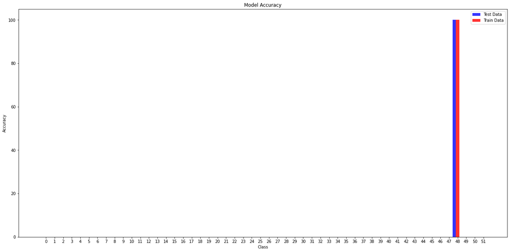

```python
test_model_accuracy_each_class(model3, test_loader3, train_loader3)
```

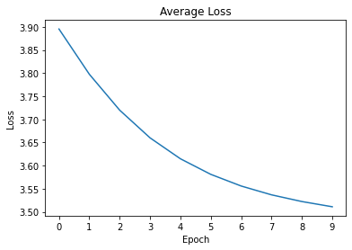

```python
draw_average_loss_plot(average_losses3)
```

## Part 6

The amount that the weights are updated during training is referred to as the step size or the “learning rate”. Specifically, the learning rate is a configurable hyperparameter used in the training of neural networks that has a small positive value, often in the range between 0.0 and 1.0. The learning rate controls how quickly the model is adapted to the problem. Smaller learning rates require more training epochs given the smaller changes made to the weights each update, whereas larger learning rates result in rapid changes and require fewer training epochs. A learning rate that is too large can cause the model to converge too quickly to a suboptimal solution, whereas a learning rate that is too small can cause the process to get stuck.

[output not shown]

As observed in the table above, too small or too big learning rates cause accuracy to drop. At extremes, a learning rate that is too large will result in weight updates that will be too large and the performance of the model (such as its loss on the training dataset) will oscillate over training epochs. Oscillating performance is said to be caused by weights that diverge (are divergent). A learning rate that is too small may never converge or may get stuck on a suboptimal solution. This phenomenon is observed in the results.

```python
transform4 = transforms.Compose([transforms.Grayscale(), CustomToTensorNormalize()])
dataset4 = ImageFolder('./categorized_products', transform=transform4)

batch_size = 64

train_loader4 = torch.utils.data.DataLoader(dataset4, batch_size=batch_size, sampler=train_sampler, num_workers=16)
test_loader4 = torch.utils.data.DataLoader(dataset4, batch_size=batch_size, sampler=test_sampler, num_workers=16)

model4 = Model(len(dataset4.classes))
model4 = model4.to(device)

optimizer4 = torch.optim.SGD(model4.parameters(), lr=0.06)
```

```python
average_losses4 = fit(model4, train_loader4, device, criterion, optimizer4)
```

```
epoch 1, train_loss: 2.752, time elapsed: 25.705861 seconds
epoch 2, train_loss: 1.961, time elapsed: 25.466744 seconds
epoch 3, train_loss: 1.700, time elapsed: 25.184196 seconds
epoch 4, train_loss: 1.552, time elapsed: 25.240587 seconds
epoch 5, train_loss: 1.354, time elapsed: 25.240448 seconds
epoch 6, train_loss: 1.252, time elapsed: 25.121353 seconds
epoch 7, train_loss: 1.190, time elapsed: 25.281216 seconds
epoch 8, train_loss: 1.109, time elapsed: 25.317969 seconds
epoch 9, train_loss: 1.064, time elapsed: 25.246566 seconds
epoch 10, train_loss: 1.021, time elapsed: 25.162159 seconds
total training time: 4.216 minutes
```

```python
print('For Test: ')
test_model_accuracy(model4, test_loader4)
print('For Train: ')
test_model_accuracy(model4, train_loader4)
```

```
For Test:
Accuracy: 67.88634231336282%
For Train:
Accuracy: 69.91525423728814%
```

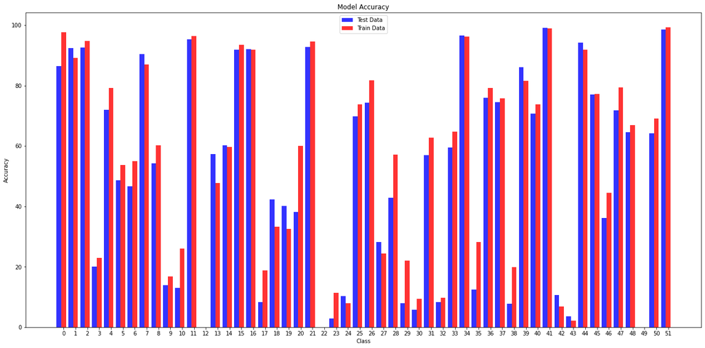

```python
test_model_accuracy_each_class(model4, test_loader4, train_loader4)
```

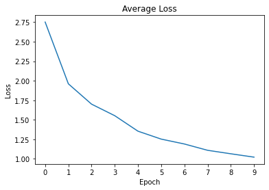

```python
draw_average_loss_plot(average_losses4)
```

## Part 7

The batch size defines the number of samples that will be propagated through the network. For instance, let's say you have 1050 training samples and you want to set up a batch_size equal to 100. The algorithm takes the first 100 samples (from 1st to 100th) from the training dataset and trains the network. Next, it takes the second 100 samples (from 101st to 200th) and trains the network again.

Now, difference between big and small batch sizes are illustrated:  
**Bigger batch size:**  
As benefits, it might not get stuck in a local optimum because there are more data to train the model in each pass. Also, in each epoch, weights might change a lot so learning is faster. However, each iteration would need more computation power and it would use more memory and large batch sizes usually converge to sharp minimizers.  
**Smaller batch size:** As benefits, smaller batch sizes are noisy, offering a regularizing effect and lower generalization error and smaller batch sizes make it easier to fit one batch worth of training data in memory. However, it might not lead to global optimum answer and small batch size converges to flat minimizers.

```python
transform5 = transforms.Compose([transforms.Grayscale(), CustomToTensorNormalize()])
dataset5 = ImageFolder('./categorized_products', transform=transform5)

batch_size = 32

train_loader5 = torch.utils.data.DataLoader(dataset5, batch_size=batch_size, sampler=train_sampler, num_workers=16)
test_loader5 = torch.utils.data.DataLoader(dataset5, batch_size=batch_size, sampler=test_sampler, num_workers=16)

model5 = Model(len(dataset5.classes))
model5 = model5.to(device)

optimizer5 = torch.optim.SGD(model5.parameters(), lr=0.06)
```

```python
average_losses5 = fit(model5, train_loader5, device, criterion, optimizer5)
```

```
epoch 1, train_loss: 2.537, time elapsed: 39.252899 seconds
epoch 2, train_loss: 1.741, time elapsed: 38.974602 seconds
epoch 3, train_loss: 1.490, time elapsed: 39.005234 seconds
epoch 4, train_loss: 1.310, time elapsed: 39.047926 seconds
epoch 5, train_loss: 1.213, time elapsed: 39.074542 seconds
epoch 6, train_loss: 1.147, time elapsed: 39.021437 seconds
epoch 7, train_loss: 1.059, time elapsed: 39.068019 seconds
epoch 8, train_loss: 1.013, time elapsed: 39.125669 seconds
epoch 9, train_loss: 0.979, time elapsed: 39.127818 seconds
epoch 10, train_loss: 0.928, time elapsed: 39.066998 seconds
total training time: 6.513 minutes
```

```python
print('For Test: ')
test_model_accuracy(model5, test_loader5)
print('For Train: ')
test_model_accuracy(model5, train_loader5)
```

```
For Test:
Accuracy: 59.10735826296743%
For Train:
Accuracy: 60.60667204735002%
```

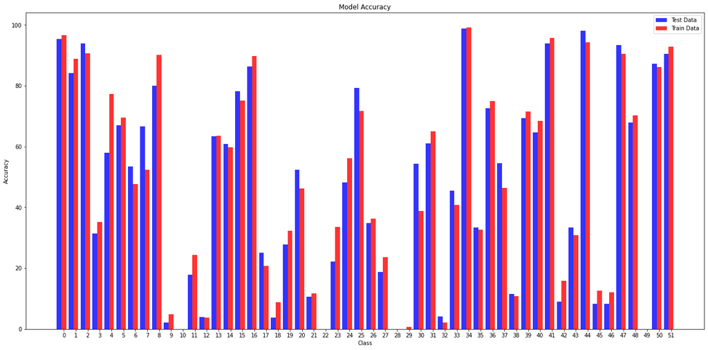

```python
test_model_accuracy_each_class(model5, test_loader5, train_loader5)
```

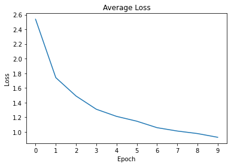

```python
draw_average_loss_plot(average_losses5)
```

```python
transform6 = transforms.Compose([transforms.Grayscale(), CustomToTensorNormalize()])
dataset6 = ImageFolder('./categorized_products', transform=transform6)

batch_size = 128

train_loader6 = torch.utils.data.DataLoader(dataset6, batch_size=batch_size, sampler=train_sampler, num_workers=16)
test_loader6 = torch.utils.data.DataLoader(dataset6, batch_size=batch_size, sampler=test_sampler, num_workers=16)

model6 = Model(len(dataset6.classes))
model6 = model6.to(device)

optimizer6 = torch.optim.SGD(model6.parameters(), lr=0.06)
```

```python
average_losses6 = fit(model6, train_loader6, device, criterion, optimizer6)
```

```
epoch 1, train_loss: 3.073, time elapsed: 16.435784 seconds
epoch 2, train_loss: 2.304, time elapsed: 16.404694 seconds
epoch 3, train_loss: 1.980, time elapsed: 16.477233 seconds
epoch 4, train_loss: 1.795, time elapsed: 16.550362 seconds
epoch 5, train_loss: 1.581, time elapsed: 16.668584 seconds
epoch 6, train_loss: 1.476, time elapsed: 16.703052 seconds
epoch 7, train_loss: 1.361, time elapsed: 16.749508 seconds
epoch 8, train_loss: 1.316, time elapsed: 16.779073 seconds
epoch 9, train_loss: 1.241, time elapsed: 16.811692 seconds
epoch 10, train_loss: 1.177, time elapsed: 16.834536 seconds
total training time: 2.774 minutes
```

```python
print('For Test: ')
test_model_accuracy(model6, test_loader6)
print('For Train: ')
test_model_accuracy(model6, train_loader6)
```

```
For Test:
Accuracy: 49.685028816512535%
For Train:
Accuracy: 51.19720204465967%
```

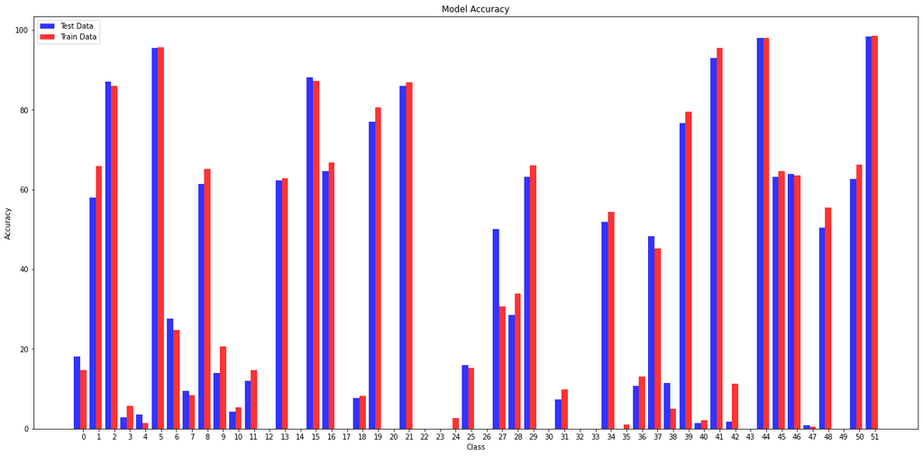

```python
test_model_accuracy_each_class(model6, test_loader6, train_loader6)
```

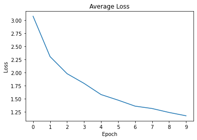

```python
draw_average_loss_plot(average_losses6)
```

As observed in the results, the model with higher learning rate is performing better and has higher accuracy. This happens because when there are higher batch sizes, the number of passes on the model reduces. When the learning rate is low, the model will gradually move to the minimum but the steps are small. However with bigger steps, the model moves toward the optimum mima faster and improves more the the model with low learning rate.

```python
transform7 = transforms.Compose([transforms.Grayscale(), CustomToTensorNormalize()])
dataset7 = ImageFolder('./categorized_products', transform=transform7)

batch_size = 128

train_loader7 = torch.utils.data.DataLoader(dataset7, batch_size=batch_size, sampler=train_sampler, num_workers=16)
test_loader7 = torch.utils.data.DataLoader(dataset7, batch_size=batch_size, sampler=test_sampler, num_workers=16)

model7 = Model(len(dataset7.classes))
model7 = model7.to(device)

optimizer7 = torch.optim.SGD(model7.parameters(), lr=0.2)
```

```python
average_losses7 = fit(model7, train_loader7, device, criterion, optimizer7)
```

```
epoch 1, train_loss: 3.490, time elapsed: 16.082555 seconds
epoch 2, train_loss: 3.316, time elapsed: 16.076083 seconds
epoch 3, train_loss: 3.072, time elapsed: 16.102681 seconds
epoch 4, train_loss: 2.832, time elapsed: 16.142732 seconds
epoch 5, train_loss: 3.327, time elapsed: 16.111807 seconds
epoch 6, train_loss: 3.182, time elapsed: 16.166097 seconds
epoch 7, train_loss: 3.003, time elapsed: 16.115701 seconds
epoch 8, train_loss: 3.321, time elapsed: 16.216899 seconds
epoch 9, train_loss: 2.962, time elapsed: 16.197807 seconds
epoch 10, train_loss: 2.839, time elapsed: 16.193796 seconds
total training time: 2.690 minutes
```

```python
print('For Test: ')
test_model_accuracy(model7, test_loader7)
print('For Train: ')
test_model_accuracy(model7, train_loader7)
```

```
For Test:
Accuracy: 24.40691596300764%
For Train:
Accuracy: 24.12227602905569%
```

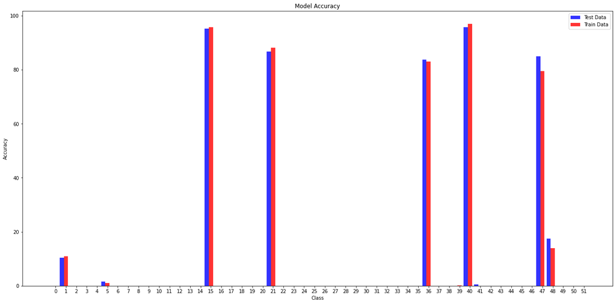

```python
test_model_accuracy_each_class(model7, test_loader7, train_loader7)
```

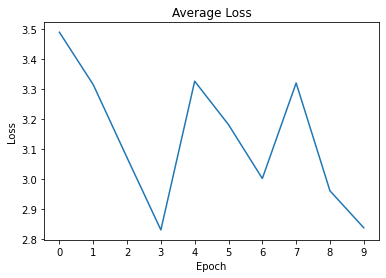

```python
draw_average_loss_plot(average_losses7)
```

```python
transform8 = transforms.Compose([transforms.Grayscale(), CustomToTensorNormalize()])
dataset8 = ImageFolder('./categorized_products', transform=transform8)

batch_size = 128

train_loader8 = torch.utils.data.DataLoader(dataset8, batch_size=batch_size, sampler=train_sampler, num_workers=16)
test_loader8 = torch.utils.data.DataLoader(dataset8, batch_size=batch_size, sampler=test_sampler, num_workers=16)

model8 = Model(len(dataset8.classes))
model8 = model8.to(device)

optimizer8 = torch.optim.SGD(model8.parameters(), lr=0.001)
```

```python
average_losses8 = fit(model8, train_loader8, device, criterion, optimizer8)
```

```
epoch 1, train_loss: 3.943, time elapsed: 16.447572 seconds
epoch 2, train_loss: 3.874, time elapsed: 16.44745 seconds
epoch 3, train_loss: 3.751, time elapsed: 16.468076 seconds
epoch 4, train_loss: 3.604, time elapsed: 16.520124 seconds
epoch 5, train_loss: 3.516, time elapsed: 16.667419 seconds
epoch 6, train_loss: 3.464, time elapsed: 16.652298 seconds
epoch 7, train_loss: 3.431, time elapsed: 16.788729 seconds
epoch 8, train_loss: 3.405, time elapsed: 16.768815 seconds
epoch 9, train_loss: 3.379, time elapsed: 16.843212 seconds
epoch 10, train_loss: 3.347, time elapsed: 16.812108 seconds
total training time: 2.774 minutes
```

```python
print('For Test: ')
test_model_accuracy(model8, test_loader8)
print('For Train: ')
test_model_accuracy(model8, train_loader8)
```

```
For Test:
Accuracy: 18.067283206004557%
For Train:
Accuracy: 18.287597524885662%
```

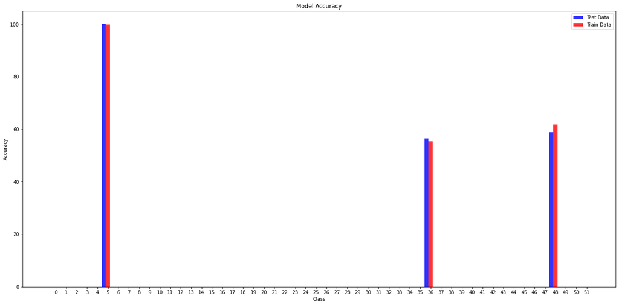

```python
test_model_accuracy_each_class(model8, test_loader8, train_loader8)
```

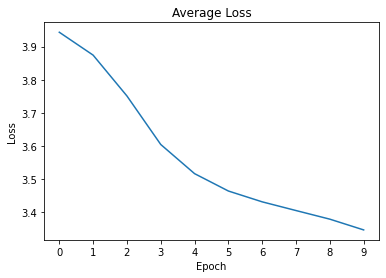

```python
draw_average_loss_plot(average_losses8)
```

## Part 8

SGD has trouble navigating ravines, i.e. areas where the surface curves much more steeply in one dimension than in another, which are common around local optima. In these scenarios, SGD oscillates across the slopes of the ravine while only making hesitant progress along the bottom towards the local optimum. Momentum is a method that helps accelerate SGD in the relevant direction and dampens oscillations. The equations of gradient descent are revised as follows.

[figure not shown]

```python
transform9 = transforms.Compose([transforms.Grayscale(), CustomToTensorNormalize()])
dataset9 = ImageFolder('./categorized_products', transform=transform9)

batch_size = 64

train_loader9 = torch.utils.data.DataLoader(dataset9, batch_size=batch_size, sampler=train_sampler, num_workers=16)
test_loader9 = torch.utils.data.DataLoader(dataset9, batch_size=batch_size, sampler=test_sampler, num_workers=16)

model9 = Model(len(dataset9.classes))
model9 = model9.to(device)

optimizer9 = torch.optim.SGD(model9.parameters(), lr=0.06, momentum=0.5)
```

```python
average_losses9 = fit(model9, train_loader9, device, criterion, optimizer9)
```

```
epoch 1, train_loss: 2.688, time elapsed: 33.094739 seconds
epoch 2, train_loss: 1.885, time elapsed: 33.213019 seconds
epoch 3, train_loss: 1.604, time elapsed: 33.150599 seconds
epoch 4, train_loss: 1.418, time elapsed: 33.175168 seconds
epoch 5, train_loss: 1.292, time elapsed: 33.124584 seconds
epoch 6, train_loss: 1.189, time elapsed: 33.168896 seconds
epoch 7, train_loss: 1.119, time elapsed: 33.189204 seconds
epoch 8, train_loss: 1.040, time elapsed: 33.172916 seconds
epoch 9, train_loss: 1.006, time elapsed: 33.238848 seconds
epoch 10, train_loss: 0.948, time elapsed: 33.202339 seconds
total training time: 5.529 minutes
```

```python
print('For Test: ')
test_model_accuracy(model9, test_loader9)
print('For Train: ')
test_model_accuracy(model9, train_loader9)
```

```
For Test:
Accuracy: 66.76048787025867%
For Train:
Accuracy: 68.64743072370192%
```

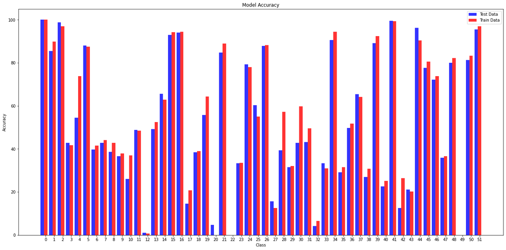

```python
test_model_accuracy_each_class(model9, test_loader9, train_loader9)
```

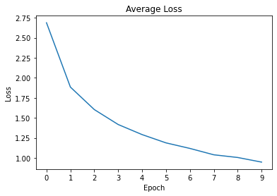

```python
draw_average_loss_plot(average_losses9)
```

```python
transform10 = transforms.Compose([transforms.Grayscale(), CustomToTensorNormalize()])
dataset10 = ImageFolder('./categorized_products', transform=transform10)

batch_size = 64

train_loader10 = torch.utils.data.DataLoader(dataset10, batch_size=batch_size, sampler=train_sampler, num_workers=16)
test_loader10 = torch.utils.data.DataLoader(dataset10, batch_size=batch_size, sampler=test_sampler, num_workers=16)

model10 = Model(len(dataset10.classes))
model10 = model10.to(device)

optimizer10 = torch.optim.SGD(model10.parameters(), lr=0.06, momentum=0.9)
```

```python
average_losses10 = fit(model10, train_loader10, device, criterion, optimizer10)
```

```
epoch 1, train_loss: 2.808, time elapsed: 60.08299 seconds
epoch 2, train_loss: 2.413, time elapsed: 59.766791 seconds
epoch 3, train_loss: 2.213, time elapsed: 59.760046 seconds
epoch 4, train_loss: 2.109, time elapsed: 59.478538 seconds
epoch 5, train_loss: 2.615, time elapsed: 59.377889 seconds
epoch 6, train_loss: 3.456, time elapsed: 59.070144 seconds
epoch 7, train_loss: 3.450, time elapsed: 59.169384 seconds
epoch 8, train_loss: 3.450, time elapsed: 59.04733 seconds
epoch 9, train_loss: 3.450, time elapsed: 59.072764 seconds
epoch 10, train_loss: 3.450, time elapsed: 59.031802 seconds
total training time: 9.898 minutes
```

```python
print('For Test: ')
test_model_accuracy(model10, test_loader10)
print('For Train: ')
test_model_accuracy(model10, train_loader10)
```

```
For Test:
Accuracy: 8.618147701380511%
For Train:
Accuracy: 8.639359698681732%
```

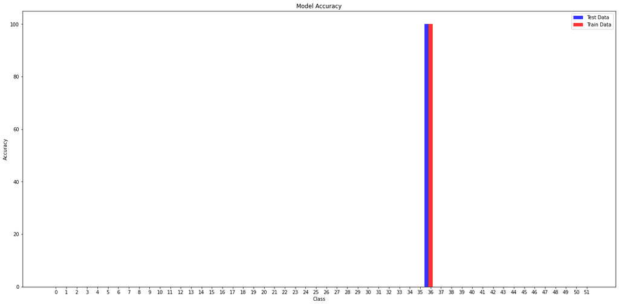

```python
test_model_accuracy_each_class(model10, test_loader10, train_loader10)
```

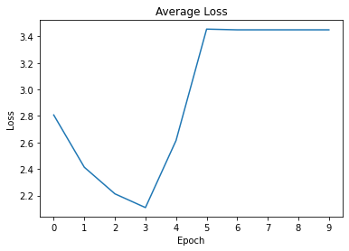

```python
draw_average_loss_plot(average_losses10)
```

```python
transform11 = transforms.Compose([transforms.Grayscale(), CustomToTensorNormalize()])
dataset11 = ImageFolder('./categorized_products', transform=transform11)

batch_size = 64

train_loader11 = torch.utils.data.DataLoader(dataset11, batch_size=batch_size, sampler=train_sampler, num_workers=16)
test_loader11 = torch.utils.data.DataLoader(dataset11, batch_size=batch_size, sampler=test_sampler, num_workers=16)

model11 = Model(len(dataset11.classes))
model11 = model11.to(device)

optimizer11 = torch.optim.SGD(model11.parameters(), lr=0.06, momentum=0.98)
```

```python
average_losses11 = fit(model11, train_loader11, device, criterion, optimizer11)
```

```
epoch 1, train_loss: 3.480, time elapsed: 59.654957 seconds
epoch 2, train_loss: 3.461, time elapsed: 59.452074 seconds
epoch 3, train_loss: 3.458, time elapsed: 59.452221 seconds
epoch 4, train_loss: 3.459, time elapsed: 59.586447 seconds
epoch 5, train_loss: 3.458, time elapsed: 59.764653 seconds
epoch 6, train_loss: 3.459, time elapsed: 59.702482 seconds
epoch 7, train_loss: 3.459, time elapsed: 59.797472 seconds
epoch 8, train_loss: 3.460, time elapsed: 59.738864 seconds
epoch 9, train_loss: 3.459, time elapsed: 59.666307 seconds
epoch 10, train_loss: 3.459, time elapsed: 59.649919 seconds
total training time: 9.941 minutes
```

```python
print('For Test: ')
test_model_accuracy(model11, test_loader11)
print('For Train: ')
test_model_accuracy(model11, train_loader11)
```

```
For Test:
Accuracy: 9.47594156279319%
For Train:
Accuracy: 9.50363196125908%
```

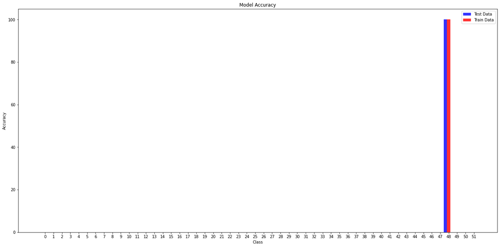

```python
test_model_accuracy_each_class(model11, test_loader11, train_loader11)
```

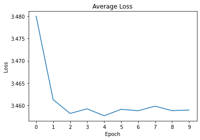

```python
draw_average_loss_plot(average_losses11)
```

## Part 9

One Epoch is when an entire dataset is passed forward and backward through the neural network only once. As the number of epochs increases, more number of times the weight are changed in the neural network and the curve goes from underfitting to optimal to overfitting curve. Having one epoch will cause under fitting and having lots of epoch will cause overfitting. So, increasing epochs wont necessarily increase our accuracy because it could cause overfitting.  
In this case, the model with 20 epoch has better accuracy than the model with 10 epochs because the model is not overfitting nor underfitting.

```python
transform12 = transforms.Compose([transforms.Grayscale(), CustomToTensorNormalize()])
dataset12 = ImageFolder('./categorized_products', transform=transform12)

batch_size = 64

train_loader12 = torch.utils.data.DataLoader(dataset12, batch_size=batch_size, sampler=train_sampler, num_workers=16)
test_loader12 = torch.utils.data.DataLoader(dataset12, batch_size=batch_size, sampler=test_sampler, num_workers=16)

model12 = Model(len(dataset12.classes))
model12 = model12.to(device)

optimizer12 = torch.optim.SGD(model12.parameters(), lr=0.06, momentum=0.5)
```

```python
average_losses12 = fit(model12, train_loader12, device, criterion, optimizer12, 20)
```

```
epoch 1, train_loss: 2.623, time elapsed: 33.493111 seconds
epoch 2, train_loss: 2.148, time elapsed: 33.429384 seconds
epoch 3, train_loss: 1.762, time elapsed: 33.282984 seconds
epoch 4, train_loss: 1.498, time elapsed: 33.346566 seconds
epoch 5, train_loss: 1.373, time elapsed: 33.346646 seconds
epoch 6, train_loss: 1.256, time elapsed: 33.347473 seconds
epoch 7, train_loss: 1.162, time elapsed: 33.370708 seconds
epoch 8, train_loss: 1.100, time elapsed: 33.394169 seconds
epoch 9, train_loss: 1.044, time elapsed: 33.396791 seconds
epoch 10, train_loss: 1.007, time elapsed: 33.401278 seconds
epoch 11, train_loss: 0.959, time elapsed: 33.364226 seconds
epoch 12, train_loss: 0.924, time elapsed: 33.338718 seconds
epoch 13, train_loss: 0.896, time elapsed: 33.348517 seconds
epoch 14, train_loss: 0.879, time elapsed: 33.471179 seconds
epoch 15, train_loss: 0.840, time elapsed: 33.458439 seconds
epoch 16, train_loss: 0.822, time elapsed: 33.43919 seconds
epoch 17, train_loss: 0.789, time elapsed: 33.318349 seconds
epoch 18, train_loss: 0.783, time elapsed: 33.411029 seconds
epoch 19, train_loss: 0.757, time elapsed: 33.289143 seconds
epoch 20, train_loss: 0.742, time elapsed: 33.286934 seconds
total training time: 11.126 minutes
```

```python
print('For Test: ')
test_model_accuracy(model12, test_loader12)
print('For Train: ')
test_model_accuracy(model12, train_loader12)
```

```
For Test:
Accuracy: 72.3361479694411%
For Train:
Accuracy: 75.52797955340328%
```

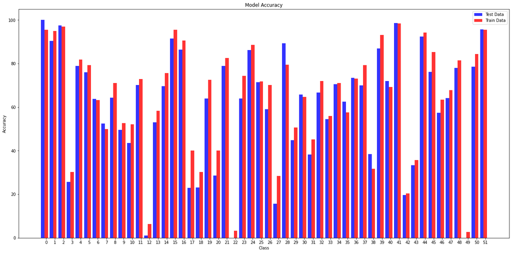

```python
test_model_accuracy_each_class(model12, test_loader12, train_loader12)
```

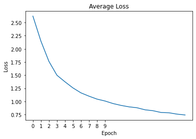

```python
draw_average_loss_plot(average_losses12)
```

## Part 10

Activation functions used are:

1. **Relu:** f(x) = max(0,x)
2. **Leaky Relu**: f(x) = 1(x<0)(αx)+1(x>=0)(x) where α is a small constant.
3. **Tanh**: f(x) = (e^x - e^-x) / (e^x + e^-x) In our case, the tanh function is working best and leaky relu and relu functions are almost the same. In tanh the advantage is that the negative inputs will be mapped strongly negative and the zero inputs will be mapped near zero in the tanh graph. This will cause the output to be smootehr and the model to work better.  
   The main difference between relu and leaky relu is that the plot is smoother in 0 in leaky relu but sharper in relu which could be seen in the below.

[figure not shown]

```python
transform13 = transforms.Compose([transforms.Grayscale(), CustomToTensorNormalize()])
dataset13 = ImageFolder('./categorized_products', transform=transform13)

batch_size = 64

train_loader13 = torch.utils.data.DataLoader(dataset13, batch_size=batch_size, sampler=train_sampler, num_workers=16)
test_loader13 = torch.utils.data.DataLoader(dataset13, batch_size=batch_size, sampler=test_sampler, num_workers=16)

model13 = Model(len(dataset13.classes), F.tanh)
model13 = model13.to(device)

optimizer13 = torch.optim.SGD(model13.parameters(), lr=0.06, momentum=0.5)
```

```python
average_losses13 = fit(model13, train_loader13, device, criterion, optimizer13)
```

```
epoch 1, train_loss: 2.121, time elapsed: 61.386295 seconds
epoch 2, train_loss: 1.399, time elapsed: 61.177907 seconds
epoch 3, train_loss: 1.225, time elapsed: 61.163594 seconds
epoch 4, train_loss: 1.134, time elapsed: 61.137026 seconds
epoch 5, train_loss: 1.045, time elapsed: 61.145062 seconds
epoch 6, train_loss: 1.008, time elapsed: 61.182109 seconds
epoch 7, train_loss: 0.958, time elapsed: 61.179617 seconds
epoch 8, train_loss: 0.914, time elapsed: 61.443253 seconds
epoch 9, train_loss: 0.882, time elapsed: 61.286102 seconds
epoch 10, train_loss: 0.856, time elapsed: 60.977941 seconds
total training time: 10.201 minutes
```

```python
print('For Test: ')
test_model_accuracy(model13, test_loader13)
print('For Train: ')
test_model_accuracy(model13, train_loader13)
```

```
For Test:
```

```
Accuracy: 71.07626323549123%
For Train:
Accuracy: 72.41727199354318%
```

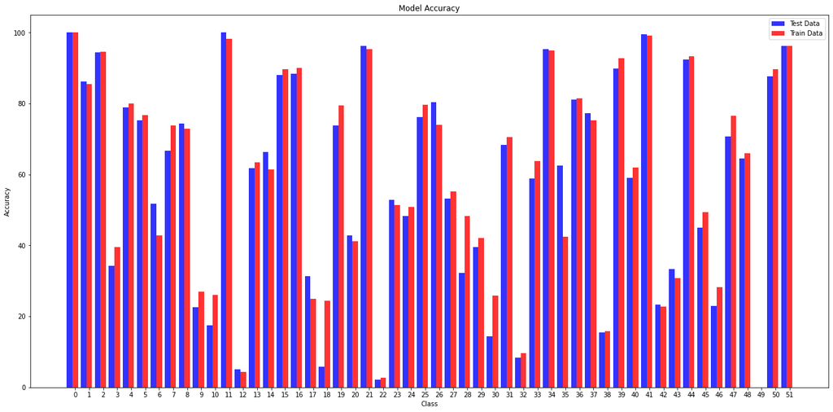

```python
test_model_accuracy_each_class(model13, test_loader13, train_loader13)
```

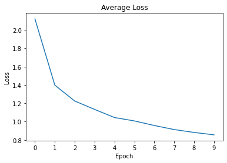

```python
draw_average_loss_plot(average_losses13)
```

```python
transform14 = transforms.Compose([transforms.Grayscale(), CustomToTensorNormalize()])
dataset14 = ImageFolder('./categorized_products', transform=transform14)

batch_size = 64

train_loader14 = torch.utils.data.DataLoader(dataset14, batch_size=batch_size, sampler=train_sampler, num_workers=16)
test_loader14 = torch.utils.data.DataLoader(dataset14, batch_size=batch_size, sampler=test_sampler, num_workers=16)

model14 = Model(len(dataset14.classes), F.leaky_relu)
model14 = model14.to(device)

optimizer14 = torch.optim.SGD(model14.parameters(), lr=0.06, momentum=0.5)
```

```python
average_losses14 = fit(model14, train_loader14, device, criterion, optimizer14)
```

```
epoch 1, train_loss: 2.939, time elapsed: 18.288545 seconds
epoch 2, train_loss: 2.015, time elapsed: 18.205881 seconds
epoch 3, train_loss: 1.640, time elapsed: 18.160079 seconds
epoch 4, train_loss: 1.578, time elapsed: 18.130805 seconds
epoch 5, train_loss: 1.381, time elapsed: 18.237202 seconds
epoch 6, train_loss: 1.256, time elapsed: 18.209642 seconds
epoch 7, train_loss: 1.174, time elapsed: 18.178716 seconds
epoch 8, train_loss: 1.110, time elapsed: 18.084284 seconds
epoch 9, train_loss: 1.039, time elapsed: 18.118129 seconds
epoch 10, train_loss: 0.989, time elapsed: 18.344361 seconds
total training time: 3.033 minutes
```

```python
print('For Test: ')
test_model_accuracy(model14, test_loader14)
print('For Train: ')
test_model_accuracy(model14, train_loader14)
```

```
For Test:
Accuracy: 65.12531832194075%
For Train:
Accuracy: 65.55690072639226%
```

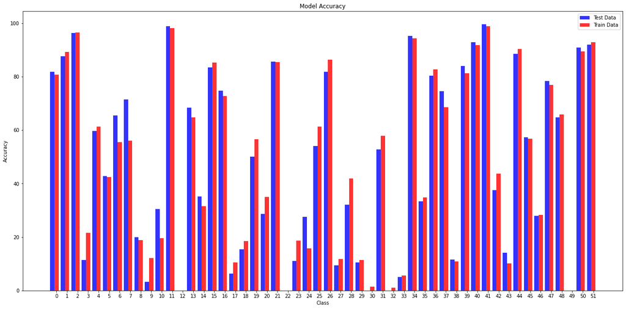

```python
test_model_accuracy_each_class(model14, test_loader14, train_loader14)
```

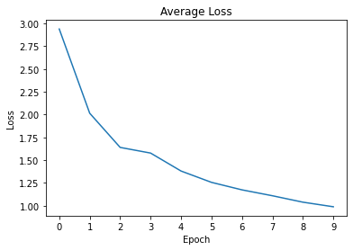

```python
draw_average_loss_plot(average_losses14)
```